# SIEM for Determination of Batch Effects in fMRI and dMRI Populations wrt Hemispheric Connectivity

Eric Bridgeford

December 31, 2017

# Model

For details on the model, please see [SIEM model](http://docs.neurodata.io/graphstats/siem/siem.html). For an expanded look at the Ipsilateral vs Contralateral Problem, see [Hemispheric Connectivity Notebook](http://docs.neurodata.io/graphstats/siem/hemispheric_within.html).

# Real Data Experiments

## Tests

### for each Graph

Our test for this notebook is as follows:

$$\begin{align*}
H_0: p_{ips} \leq p_{contra} \\
H_A: p_{ips} > p_{contra}
\end{align*}$$

We will use a $1$-sample test to determine whether within a single graph we can determine a significant difference in connectivity.

We will perform this experiment for both dMRI and fMRI-derived connectomes.

### for Determining a Batch

To determine a batch’s test statistic, we will simply attempt to assess the magnitude of the differences in model fit between each pair of batches. To acquire a p-value, we will use a permutation-based approach. That is:

```
test_statistic(models, grouping):
  compute the average p_{ipsi} and p_{contra} for the graphs within each unique grouping label.
  For each i, j pair of unique grouping labels:
    stat[i, j] = |p_{ipsi, 1} - p_{ipsi, 2} - (p_{contra, 1} - p_{contra, 2})|
  return max(stats)  # test statistic is the pairing with the greatest magnitude

permutation_test(models, batch_grouping):
  compute the test statistic for the graphs given the default batch grouping.
  For i in 1:nrepetitions:
    permute the batch grouping to obtain a permuted grouping.
    compute the test statistic for the models given the permuted grouping.
  Compute the fraction of permuted test statistics > the given test statistic.
```

Or the fraction of times that the maximum magnitude of a model fit difference exceeds the observed maximum magnitude of a model fit difference.

```r
get_results <- function(tstat.out) {
  P <- tstat.out$P
  return(P[upper.tri(P, diag=FALSE)])
}

case.experiment.within <- function(models, datasets.labs, split.labs, modal, nrep=1000) {
  # partition the models that do not have the split data
  include_sets <- which(!is.nan(split.labs))
  incl.models <- models[include_sets]
  incl.datasets.labs <- datasets.labs[include_sets]
  incl.split.labs <- split.labs[include_sets]

  dsets <- unique(incl.datasets.labs)
  results <- data.frame(dataset=c(), pval=c())

  for (i in 1:length(dsets)) {
    ss <- which(incl.datasets.labs == dsets[i])
    model_ss <- incl.models[ss]  # subset one dataset of models
    split_ss <- incl.split.labs[ss]
    if (length(unique(split_ss)) > 1) {
      perm.result <- gs.siem.batch.perm(model_ss, split_ss, i=1, j=2, nperm=nrep)
      results <- rbind(results, data.frame(dataset=dsets[i], pval=get_results(perm.result), modal=modal))
    }
  }
  return(results)
}


case.experiment.between <- function(models, datasets.labs, modal, nrep=1000) {
  # partition the models that do not have the split data
  include_sets <- which(!is.nan(datasets.labs))
  models <- models[include_sets]
  datasets.labs <- datasets.labs[include_sets]

  dsets <- unique(datasets.labs)
  results <- data.frame(dataset=c(), pval=c())

  perm.result <- gs.siem.batch.perm(models, datasets.labs, i=1, j=2, nperm=nrep)
  results <- rbind(results, data.frame(dataset='set', pval=get_results(perm.result), modal=modal))
  return(results)
}

case.experiment.pairwise <- function(models, datasets.labs, modal, nrep=1000) {
  # partition the models that do not have the split data
  include_sets <- which(!is.nan(datasets.labs))
  models <- models[include_sets]
  datasets.labs <- datasets.labs[include_sets]

  dsets <- unique(datasets.labs)
  results <- data.frame(dset1=c(), dset2=c(), pval=c(), modality=c())
  D <- array(0, dim=c(length(dsets), length(dsets)))
  for (i in 1:(length(dsets) - 1)) {
    for (j in ((i+1):length(dsets))) {
      ss <- datasets.labs %in% c(dsets[i], dsets[j])
      perm.result <- gs.siem.batch.perm(models[ss], datasets.labs[ss], i=1, j=2, nperm=nrep)
      results <- rbind(results, data.frame(dset1=dsets[i], dset2=dsets[j], pval=get_results(perm.result), modal=modal))
      D[i, j] <- get_results(perm.result)
    }
  }

  D <- D + t(D) - diag(diag(D))
  diag(D) <- 1  # no batch between same dataset
  return(list(data=results, D=D, dsets=dsets))
}

g_legend <- function(a.gplot){
  tmp <- ggplot_gtable(ggplot_build(a.gplot))
  leg <- which(sapply(tmp$grobs, function(x) x$name) == "guide-box")
  legend <- tmp$grobs[[leg]]
  return(legend)
}

is.defined = function(x)!is.null(x)

extract_params <- function(models, Z, i=1, j=2, modal=NULL) {
# aggregate p and qs
  params <- lapply(unique(Z), function(z) {
    ss <- which(Z == z)
    mods <- dwi.models[ss]
    p <- sapply(mods, function(model) model$pr[i])
    q <- sapply(mods, function(model) model$pr[j])
    pm <- mean(p); qm <- mean(q); dm <- pm - qm
    return(data.frame(p=pm, q=qm, d=dm, dataset=z, size=length(ss), modal=modal))
  })
  return(do.call(rbind, params))
}
```

## Raw Data

The data below can be downloaded and moved to appropriate folders as follows (note that the below section requires sudo access):

```
sudo mkdir /data/
sudo chmod -R 777 /data

cd /data
wget http://openconnecto.me/mrdata/share/derivatives/dwi_edgelists.tar.gz
wget http://openconnecto.me/mrdata/share/derivatives/fmri_edgelists.tar.gz
wget http://openconnecto.me/mrdata/share/connectome_stats/connectome_stats.zip

mkdir -p /data/connectome_stats /data/all_mr /data/all_mr/dwi/edgelists /data/all_mr/fmri/ranked/edgelists
mv dwi_edgelists.tar.gz /data/dwi/edgelists
cd /data/dwi/edgelists
tar -xvzf dwi_edgelists.tar.gz
mv /data/fmri_edgelists.tar.gz /data/fmri/ranked/edgelists
cd /data/fmri/ranked/edgelists
tar -xvzf fmri_edgelists.tar.gz
mv /data/connectome_stats.zip /data/connectome_stats.zip
cd /data/connectome_stats
unzip connectome_stats.zip
```

## Diffusion

```r
nroi <- 70
dwi.dsets = c('BNU1', 'BNU3', 'HNU1', 'KKI2009', 'NKI1', 'NKIENH', 'MRN1313', 'Templeton114', 'Templeton255', 'SWU4')
dwi.atlas = 'desikan'
dwi.basepath = '/data/all_mr/dwi/edgelists'

graphobj = fmriu.io.collection.open_graphs(basepath = dwi.basepath, atlases = dwi.atlas, datasets = dwi.dsets,
                                           gname = 'graphs', fmt='edgelist', rtype = 'array')
```

```
## [1] "opening graphs for BNU1 dataset and desikan parcellation atlas..."
## [1] "opening graphs for BNU3 dataset and desikan parcellation atlas..."
## [1] "opening graphs for HNU1 dataset and desikan parcellation atlas..."
## [1] "opening graphs for KKI2009 dataset and desikan parcellation atlas..."
## [1] "opening graphs for NKI1 dataset and desikan parcellation atlas..."
## [1] "opening graphs for NKIENH dataset and desikan parcellation atlas..."
## [1] "opening graphs for MRN1313 dataset and desikan parcellation atlas..."
## [1] "opening graphs for Templeton114 dataset and desikan parcellation atlas..."
## [1] "opening graphs for Templeton255 dataset and desikan parcellation atlas..."
## [1] "opening graphs for SWU4 dataset and desikan parcellation atlas..."
```

```r
dwi.graphs = graphobj$graphs
dwi.datasets = graphobj$dataset
dwi.subjects = graphobj$subjects
dwi.sessions = graphobj$sessions

sexpath = '/data/all_mr/phenotypic/'
class = parse_class(sexpath, dwi.dsets, dwi.subjects)
dwi.sexs = class$sex
```

```r
ne = 1225
nroi <- 70
group1 <- c()  # edges in same hemisphere
group2 <- c()  # edges across hemispheres
for (i in 1:nroi) {
  for (j in 1:nroi) {
    idx <- (i - 1)*nroi + j
    if ((i <= 35 & j <= 35) | (i > 35 & j > 35)) {
      group1 <- c(group1, idx)
    } else {
      group2 <- c(group2, idx)
    }
  }
}
Es <- list(group1, group2)
dwi.rank.graphs <- gs.xfm.aaply(dwi.graphs, gs.xfm.rank_graph)
dwi.models <- suppressWarnings(gs.xfm.alply(dwi.rank.graphs, gs.siem.fit, Es))
incl <- which(sapply(dwi.models, is.defined))
dwi.datasets <- dwi.datasets[incl]
dwi.sessions <- dwi.sessions[incl]
dwi.sexs <- dwi.sexs[incl]
dwi.subjects <- dwi.subjects[incl]
dwi.models <- dwi.models[incl]
```

# Functional

```r
nroi <- 70
fmri.dsets = c('BNU1', 'BNU2', 'BNU3', 'HNU1', 'IBATRT', 'IPCAS1', 'IPCAS2', 'IPCAS5', 'IPCAS6', 'IPCAS8', 'MRN1', 'NYU1', 'SWU1', 'SWU2', 'SWU3', 'SWU4', 'UWM', 'XHCUMS')
fmri.atlas = 'desikan-2mm'
fmri.basepath = '/data/all_mr/fmri/ranked/edgelists/'

graphobj = fmriu.io.collection.open_graphs(basepath = fmri.basepath, atlases = fmri.atlas, datasets=fmri.dsets, fmt='edgelist', rtype = 'array')
```

```
## [1] "opening graphs for BNU1 dataset and desikan-2mm parcellation atlas..."
## [1] "opening graphs for BNU2 dataset and desikan-2mm parcellation atlas..."
## [1] "opening graphs for BNU3 dataset and desikan-2mm parcellation atlas..."
## [1] "opening graphs for HNU1 dataset and desikan-2mm parcellation atlas..."
## [1] "opening graphs for IBATRT dataset and desikan-2mm parcellation atlas..."
## [1] "opening graphs for IPCAS1 dataset and desikan-2mm parcellation atlas..."
## [1] "opening graphs for IPCAS2 dataset and desikan-2mm parcellation atlas..."
## [1] "opening graphs for IPCAS5 dataset and desikan-2mm parcellation atlas..."
## [1] "opening graphs for IPCAS6 dataset and desikan-2mm parcellation atlas..."
## [1] "opening graphs for IPCAS8 dataset and desikan-2mm parcellation atlas..."
## [1] "opening graphs for MRN1 dataset and desikan-2mm parcellation atlas..."
## [1] "opening graphs for NYU1 dataset and desikan-2mm parcellation atlas..."
## [1] "opening graphs for SWU1 dataset and desikan-2mm parcellation atlas..."
## [1] "opening graphs for SWU2 dataset and desikan-2mm parcellation atlas..."
## [1] "opening graphs for SWU3 dataset and desikan-2mm parcellation atlas..."
## [1] "opening graphs for SWU4 dataset and desikan-2mm parcellation atlas..."
## [1] "opening graphs for UWM dataset and desikan-2mm parcellation atlas..."
## [1] "opening graphs for XHCUMS dataset and desikan-2mm parcellation atlas..."
```

```r
fmri.graphs = graphobj$graphs
fmri.datasets = graphobj$dataset
fmri.subjects = graphobj$subjects
fmri.sessions <- graphobj$sessions

sexpath = '/data/all_mr/phenotypic/'
class = parse_class(sexpath, fmri.dsets, fmri.subjects)
```

[output not shown]

```r
fmri.sexs = class$sex
```

```r
ne = 1225
nroi <- 70
group1 <- c()  # edges in same hemisphere
group2 <- c()  # edges across hemispheres
for (i in 1:nroi) {
  for (j in 1:nroi) {
    idx <- (i - 1)*nroi + j
    if ((i <= 35 & j <= 35) | (i > 35 & j > 35)) {
      group1 <- c(group1, idx)
    } else {
      group2 <- c(group2, idx)
    }
  }
}
Es <- list(group1, group2)
fmri.rank.graphs <- gs.xfm.aaply(fmri.graphs, gs.xfm.rank_graph)
fmri.models <- suppressWarnings(gs.xfm.alply(fmri.rank.graphs, gs.siem.fit, Es))

incl <- which(sapply(fmri.models, is.defined))
fmri.datasets <- fmri.datasets[incl]
fmri.sessions <- fmri.sessions[incl]
fmri.sexs <- fmri.sexs[incl]
fmri.subjects <- fmri.subjects[incl]
fmri.models <- fmri.models[incl]
```

Map a color vector:

```r
total.dsets <- union(dwi.datasets, fmri.datasets)
cols <- c("#d5512b","#5970d8","#99b534","#9e5cd0","#59b648","#c74bae","#4bbe7c","#d93f7f",
          "#387e4a","#d2414f","#4ebdb0","#d98d2f","#5e98d3","#c6ab43","#725a9d","#99b36d",
          "#b98ed8","#677629","#d77fb9","#92692e","#9c4467","#e1966c","#dc7b88","#ac5336")
names(cols) <- total.dsets
```

# Pre-Experimental: Visualizing P and Q across Studies

```r
dwi.params <- extract_params(dwi.models, dwi.datasets, i=1, j=2, modal='dMRI')
fmri.params <- extract_params(fmri.models, fmri.datasets, i=1, j=2, modal='fMRI')
params <- rbind(dwi.params, fmri.params)
colnames(params)[3] <- "p - q"
# params <- melt(params, id=c("dataset", "modal", "size"))
# plot_pre <- ggplot(params, aes(x=modal, y=value, shape=variable, size=size, color=dataset)) +
#   geom_jitter() +
#   scale_shape_discrete(breaks = c("p", "q", "p - q")) +
#   xlab("Modality") +
#   ylab("Value") +
#   theme_bw() +
#   guides(size=FALSE) +
#   ggtitle("Exploratory Analysis of Within-Dataset Rank") +
#   labs(shape="Variable", color="Dataset")
plot_pre <- ggplot(params, aes(x=p, y=q, shape=modal, size=size, color=dataset)) +
  geom_point() +
  scale_color_manual(values=cols) +
  xlab(TeX("$\\hat{p}$")) +
  ylab(TeX("$\\hat{q}$")) +
  theme_bw() +
  guides(size=FALSE) +
  ggtitle("Exploratory Analysis") +
  labs(shape="Modality", color="Dataset")
```

# Case 1: Session Partitioning

- Is there a batch effect between sessions of a particular study?

## Procedure

1. Compute test statistic given the default partitioning, and obtain $\tau_{observed}$, as the maximum magnitude of difference in ipsilateral vs. contralateral connectivity between any pair of 2 sessions.
2. permute the set labels of the combined set $nperm$ times (maintaining sex of each graph) to obtain the distribution of $\tau_{null}$, reporting $\hat{p}$, the estimator of $\mathbb{E}\left[\tau_{null} < \tau_{observed}\right]$

```r
results1 <- rbind(case.experiment.within(dwi.models, dwi.datasets, dwi.sessions, 'dMRI', nrep=1000),
      case.experiment.within(fmri.models, fmri.datasets, fmri.sessions, 'fMRI', nrep=1000))
saveRDS(results1, 'results_bil_case1.rds')
```

```r
results1 <- readRDS('results_bil_case1.rds')
plot1 <- ggplot(results1, aes(x=modal, y=pval, shape=modal, color=dataset, group=dataset)) +
  scale_color_manual(values=cols) +
  geom_jitter(size=2) +
  ggtitle("Case 1: Sessions") +
  ylab(TeX("$p$-Value")) +
  xlab("Modality") +
  scale_y_continuous(trans=log10_trans(), limits=c(.001, 1), breaks=c(.001, .001, .01, .1, 1)) +
  labs(shape="Modality", color="Dataset") +
  guides(color=guide_legend(ncol=2), shape=FALSE) +
  theme_bw()
```

# Case 2: Subject Partitioning

- Is there a batch effect between subjects in a particular study?

## Procedure

1. Compute test statistic given the default partitioning, and obtain $\tau_{observed}$, as the maximum magnitude of difference in ipsilateral vs. contralateral connectivity between any pair of 2 subjects.
2. permute the set labels of the combined set $nperm$ times (maintaining sex of each graph) to obtain the distribution of $\tau_{null}$, reporting $\hat{p}$, the estimator of $\mathbb{E}\left[\tau_{null} < \tau_{observed}\right]$

```r
results2 <- rbind(case.experiment.within(dwi.models, dwi.datasets, dwi.subjects, 'dMRI', nrep=100),
      case.experiment.within(fmri.models, fmri.datasets, fmri.subjects, 'fMRI', nrep=100))
saveRDS(results2, 'results_bil_case2.rds')
```

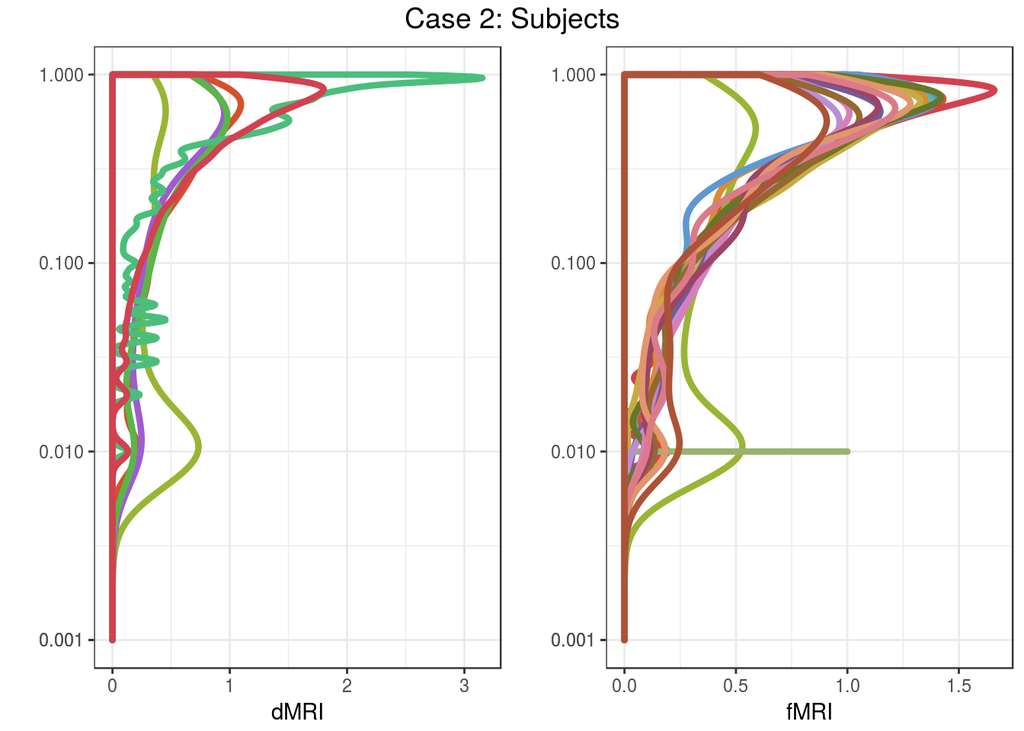

```r
results2 <- readRDS('results_bil_case2.rds')
dwi.plot2 <- ggplot(results2[results2$modal == 'dMRI',], aes(pval, color=dataset)) +
  geom_density(alpha=0.2, size=1.5) +
  scale_color_manual(values=cols) +
  xlab("") +
  coord_flip() +
  ylab("") +
  theme_bw() +
  scale_x_continuous(trans=log10_trans(), limits=c(.001, 1), breaks=c(.001, .001, .01, .1, 1))

fmri.plot2 <- ggplot(results2[results2$modal == 'fMRI',], aes(pval, color=dataset)) +
  geom_density(alpha=0.2, size=1.5) +
  scale_color_manual(values=cols) +
  xlab("") +
  coord_flip() +
  ylab("") +
  theme_bw() +
  scale_x_continuous(trans=log10_trans(), limits=c(.001, 1), breaks=c(.001, .001, .01, .1, 1))
plot2 <- grid.arrange(dwi.plot2 + theme(legend.position=NaN) + ylab("dMRI"),
                      fmri.plot2 + theme(legend.position=NaN) + ylab("fMRI"),
                      nrow=1, top = textGrob("Case 2: Subjects",gp=gpar(fontsize=14)))
```

# Case 3: Same Sex

- Is there a batch effect between sexs in a particular study?

## Procedure

1. Compute test statistic given the default partitioning, and obtain $\tau_{observed}$, as the maximum magnitude of difference in ipsilateral vs. contralateral connectivity between any pair of 2 subjects.
2. permute the set labels of the combined set $nperm$ times (maintaining sex of each graph) to obtain the distribution of $\tau_{null}$, reporting $\hat{p}$, the estimator of $\mathbb{E}\left[\tau_{null} < \tau_{observed}\right]$

```r
results3 <- rbind(case.experiment.within(dwi.models, dwi.datasets, dwi.sexs, 'dMRI', nrep=1000),
      case.experiment.within(fmri.models, fmri.datasets, fmri.sexs, 'fMRI', nrep=1000))
saveRDS(results3, 'results_bil_case3.rds')
```

```r
results3 <- readRDS('results_bil_case3.rds')
plot3 <- ggplot(results3, aes(x=modal, y=pval, shape=modal, group=dataset, color=dataset)) +
  geom_jitter(size=2) +
  scale_color_manual(values=cols) +
  ggtitle("Case 3: Same Sex") +
  xlab("") +
  ylab("") +
  scale_y_continuous(trans=log10_trans(), limits=c(.001, 1), breaks=c(.001, .001, .01, .1, 1)) +
  theme_bw()
```

# Case 4: Same Site

- Is there a batch effect between studies with site held fixed?

## Procedure

1. Compute test statistic given the default partitioning, and obtain $\tau_{observed}$, as the maximum magnitude of difference in ipsilateral vs. contralateral connectivity between any pair of 2 subjects.
2. permute the set labels of the combined set $nperm$ times (maintaining sex of each graph) to obtain the distribution of $\tau_{null}$, reporting $\hat{p}$, the estimator of $\mathbb{E}\left[\tau_{null} < \tau_{observed}\right]$

```r
dwi.studies <- dwi.datasets
fmri.studies <- fmri.datasets
dwi.studies[dwi.studies == 'BNU1' | dwi.studies == 'BNU3'] <- 'BNU'
fmri.studies[fmri.studies == 'BNU1' | fmri.studies == 'BNU3'] <- 'BNU'
dwi.studies[dwi.studies == 'Templeton114' | dwi.studies == 'Templeton255'] <- 'Templeton'

results4 <- rbind(case.experiment.within(dwi.models, dwi.studies, dwi.datasets, 'dMRI', nrep=1000),
      case.experiment.within(fmri.models, fmri.studies, fmri.datasets, 'fMRI', nrep=1000))
saveRDS(results4, 'results_bil_case4.rds')
```

```r
results4 <- readRDS('results_bil_case4.rds')
plot4 <- ggplot(results4, aes(x=modal, y=pval, shape=modal, color=dataset, group=dataset)) +
  geom_jitter(size=2) +
  ggtitle("Case 4: Same Site") +
  xlab("") +
  ylab("") +
  scale_y_continuous(trans=log10_trans(), limits=c(.001, 1), breaks=c(.001, .001, .01, .1, 1)) +
  labs(shape="Modality", color="Site") +
  theme_bw()
```

# Case 5: Same Demographics

- Is there a batch effect between studies with demographic held fixed?

## Procedure

1. Compute test statistic given the default partitioning, and obtain $\tau_{observed}$, as the maximum magnitude of difference in ipsilateral vs. contralateral connectivity between any pair of 2 subjects.
2. permute the set labels of the combined set $nperm$ times (maintaining sex of each graph) to obtain the distribution of $\tau_{null}$, reporting $\hat{p}$, the estimator of $\mathbb{E}\left[\tau_{null} < \tau_{observed}\right]$

```r
dwi.dset.sset <- which(dwi.datasets %in% c('BNU1', 'SWU4', 'HNU1', 'BNU3'))
dwi.models.subs  <- dwi.models[dwi.dset.sset]; dwi.datasets.subs <- dwi.datasets[dwi.dset.sset]

fmri.dset.sset <- which(fmri.datasets %in% c('BNU1', 'SWU4', 'HNU1', 'BNU3'))
fmri.models.subs  <- fmri.models[fmri.dset.sset]; fmri.datasets.subs <- fmri.datasets[fmri.dset.sset]

results5 <- rbind(case.experiment.pairwise(dwi.models.subs, dwi.datasets.subs, 'dMRI', nrep=1000)$data,
      case.experiment.pairwise(fmri.models.subs, fmri.datasets.subs, 'fMRI', nrep=1000)$data)
saveRDS(results5, 'results_bil_case5.rds')
```

```r
results5 <- readRDS('results_bil_case5.rds')
plot5 <- ggplot(results5, aes(x=modal, y=pval, color=dset1, shape=modal)) +
  geom_jitter(size=2) +
  ggtitle("Case 5: Same Demographic") +
  scale_color_manual(values=cols) +
  xlab("") +
  ylab("") +
  scale_y_continuous(trans=log10_trans(), limits=c(.001, 1), breaks=c(.001, .001, .01, .1, 1)) +
  theme_bw()
```

# Case 6: Disparate Demographics

- Is there a batch effect between studies without demographic held fixed?

## Procedure

1. Compute test statistic given the default partitioning, and obtain $\tau_{observed}$, as the maximum magnitude of difference in ipsilateral vs. contralateral connectivity between any pair of 2 subjects.
2. permute the set labels of the combined set $nperm$ times (maintaining sex of each graph) to obtain the distribution of $\tau_{null}$, reporting $\hat{p}$, the estimator of $\mathbb{E}\left[\tau_{null} < \tau_{observed}\right]$

```r
results6 <- rbind(case.experiment.pairwise(dwi.models, dwi.datasets, 'dMRI', nrep=1000)$data,
      case.experiment.pairwise(fmri.models, fmri.datasets, 'fMRI', nrep=1000)$data)
saveRDS(results6, 'results_bil_case6.rds')
```

```r
results6 <- readRDS('results_bil_case6.rds')
plot6 <- ggplot(results6, aes(x=modal, y=pval, color=dset1, shape=modal)) +
  geom_jitter(size=2) +
  ggtitle("Case 6: Disparate Demographic") +
  scale_color_manual(values=cols) +
  xlab("") +
  ylab("") +
  scale_y_continuous(trans=log10_trans(), limits=c(.001, 1), breaks=c(.001, .001, .01, .1, 1)) +
  theme_bw()
```

# Pairwise Study Comparison

- Is there a batch effect between all pairs of studies?

## Procedure

1. Compute test statistic given the default partitioning, and obtain $\tau_{observed}$, as the maximum magnitude of difference in ipsilateral vs. contralateral connectivity between any pair of 2 subjects.
2. permute the set labels of the combined set $nperm$ times (maintaining sex of each graph) to obtain the distribution of $\tau_{null}$, reporting $\hat{p}$, the estimator of $\mathbb{E}\left[\tau_{null} < \tau_{observed}\right]$

```r
dwi_pair_results <- case.experiment.pairwise(dwi.models, dwi.datasets, 'dMRI', nrep=1000)
fmri_pair_results <- case.experiment.pairwise(fmri.models, fmri.datasets, 'fMRI', nrep=1000)
results_pair <- list(dwi_pair_results, fmri_pair_results)
saveRDS(results_pair, 'results_bil_pair.rds')
```

# Results

## Cases

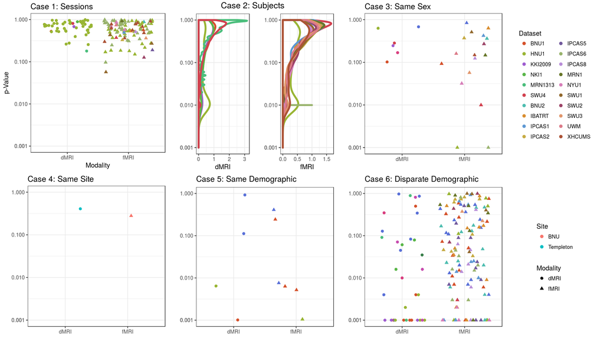

```r
results_pair <- readRDS('results_bil_pair.rds')
dwi_pair_results <- results_pair[[1]]
fmri_pair_results <- results_pair[[2]]
top_leg <- g_legend(plot1)
bot_leg <- g_legend(plot4)
bottom <- grid.arrange(arrangeGrob(plot1 + theme(legend.position=NaN),
                         plot2,
                         plot3 + theme(legend.position=NaN),
                         plot4 + theme(legend.position=NaN),
                         plot5 + theme(legend.position=NaN),
                         plot6 + theme(legend.position=NaN), nrow=2),
             arrangeGrob(top_leg, bot_leg, nrow=2), nrow=1, widths=c(0.82, 0.16))
```

## Pairwise Comparisons

### DWI

```r
dwi.pair <- gs.plot.plot_matrix(dwi_pair_results$D, vfactor = TRUE, xlabel="Dataset", ylabel="Dataset",
                    vlist = dwi_pair_results$dsets, legend.name=TeX("$log_{10}(p)$"),
                    title = "DWI Paired Batch") +
  scale_fill_gradient(name=TeX("$p$-value"), trans="log", breaks=c(0.001, 0.01, 0.1, 1),
                      limits=c(0.001, 1), low="red", high="white")
```

```
## which will replace the existing scale.
```

### fMRI

```r
fmri.pair <- gs.plot.plot_matrix(fmri_pair_results$D, vfactor = TRUE,
                                 xlabel="Dataset", ylabel="Dataset",
                    vlist = fmri_pair_results$dsets, legend.name=TeX("$log_{10}(p)$"),
                    title = "fMRI Paired Batch") +
  scale_fill_gradient(name=TeX("$p$-value"), trans="log", breaks=c(0.001, 0.01, 0.1, 1),
                      limits=c(0.001, 1), low="red", high="white")
```

```
## which will replace the existing scale.
```

# Combined plot

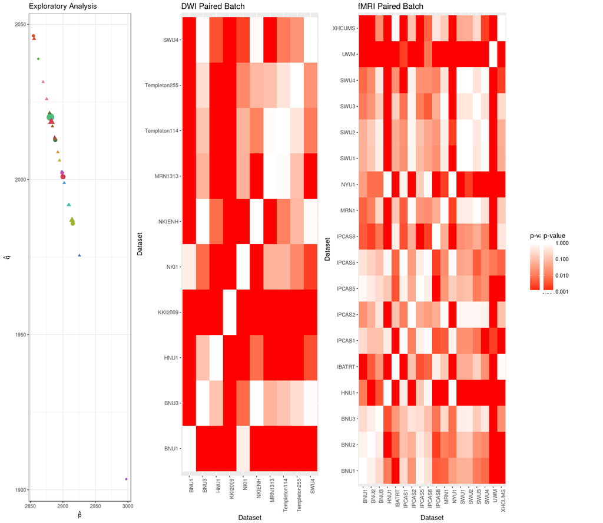

```r
pair_leg <- g_legend(dwi.pair)
top <- grid.arrange(plot_pre + theme(legend.position=NaN),
                     grid.arrange(dwi.pair + theme(legend.position=NaN),
                                  fmri.pair + theme(legend.position=NaN),
                                  pair_leg, widths=c(0.4, 0.4, 0.2)),
                     widths=c(0.2, 0.7), nrow=1)
```

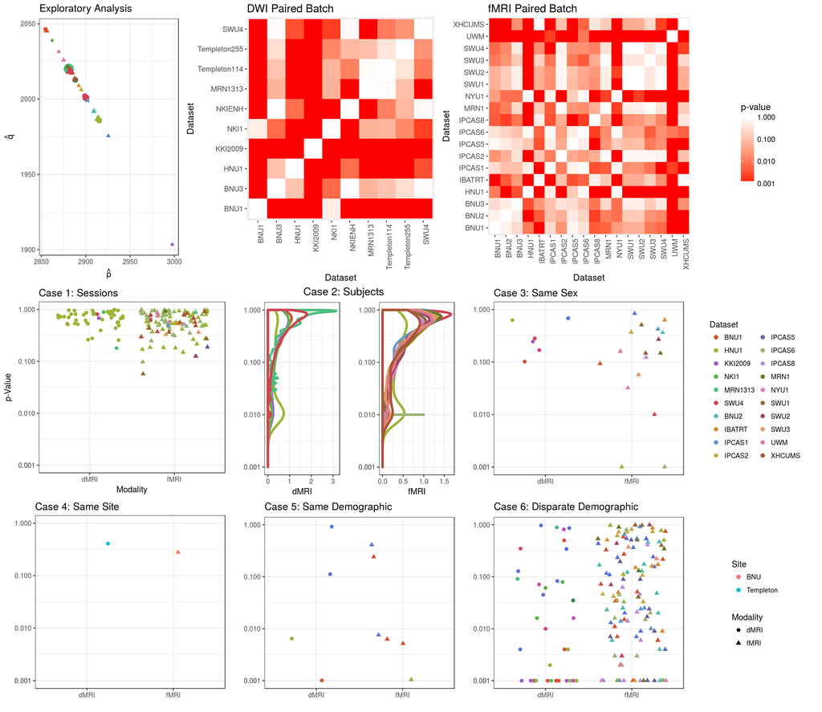

```r
grid.arrange(top, bottom, heights=c(0.4, 0.6))
```